# Initial ExPeCT Data Analysis, Subjective Focus

Bryan Stanfill  
January 16, 2018

### Questionnaire & Exercise Perspective Goals

- To determine changes in lifestyle questionnaires at three time points
  - Stress
  - Depression
  - Sleep
  - Quality of Life
- Compare the results of questionnaires between exercise and non-exercise participants at three time points
- To determine the impact of patients' adherence to the exercise program on lifestyle questionnaires

### Notes

- Some participants have complete questionnaire results but were marked as EXCLUDED in the CTC master file (Exp023, G-011, G-018 and G-032). I excluded those participants from the following analysis.
- These results are based on the updated data file “ExPeCT Sub Results Jan'18.xlsx”

### Adherence to PA Guidelines

- I used the reported overall MET hours per week to measure adherence to PA guidelines
- Two people in the Irish group have a large impact on the model results

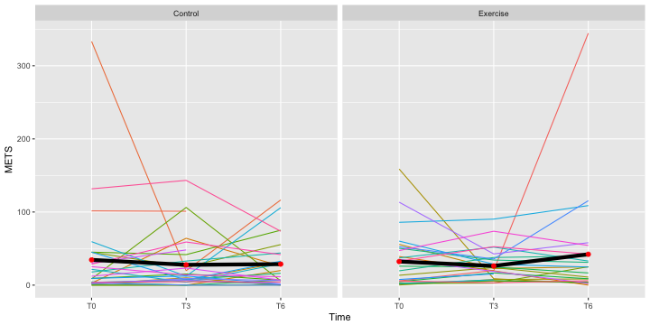

### Adherence to PA Guidelines

- I removed those individuals and fit the model again
- With them removed, there is a borderline significant difference between the exercise group in London versus the other groups, though that's likely due to the small sample size in the T6, London, Exercise group

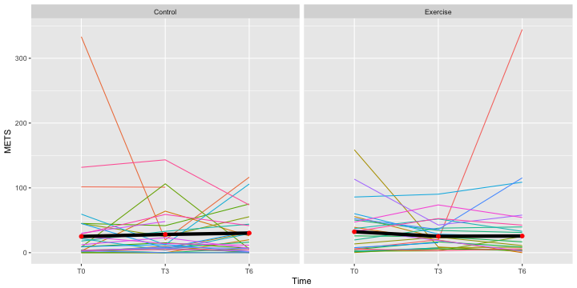

### Analysis for Other Questions

- Mixed linear models similar to those described in [Chen et al. (2015)](https://www.nature.com/articles/bjc2014612) were fit to each of the scores
- Let \( i \) indicate group (exercise/control), \( j \) indicate location (England/Ireland), \( k \) indicate person and \( t \) time point then

\[ y_{ijk}(t)=\mu+\alpha_i+\beta_j+\tau(t)+\delta_{ijk}+e_{ijk}(t) \] where \[ \delta_{ijk}\sim N(0,\sigma_p^2)\;\;\text{ indep } e_{ijk}(t)\sim N(0,\sigma^2), \]

\( \sigma_p \) is the within patient variance and \( \sigma^2 \) is the residual variance

- More complicated models including interaction terms, e.g. a time-by-treatment effect \( \gamma_{i}(t) \), were also tested but were typically inferior that the simpler model above

### Stress Analysis

- The lines represent the model predicted survey scores by time and treatment
- A location effect was included in the model but averaged out before plotting
- The interaction term is not statistically significant (right figure)

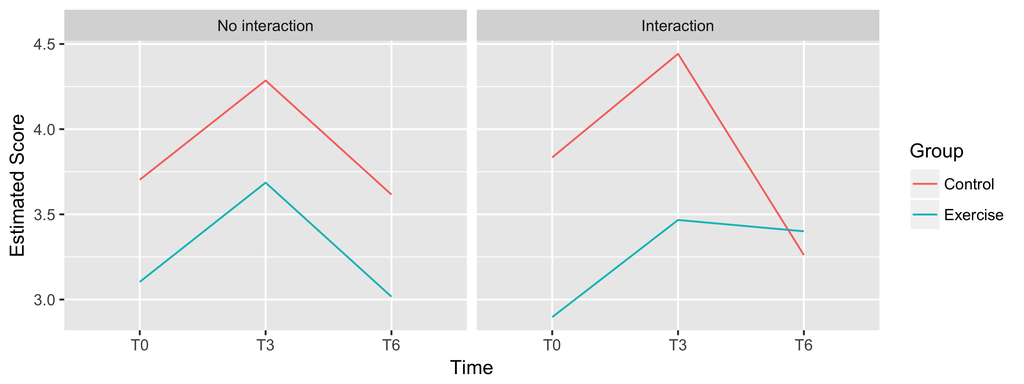

### Depression Analysis

- The lines represent the model predicted survey scores by time and treatment
- A location effect was included in the model but averaged out before plotting
- The interaction term is not statistically significant (right figure)

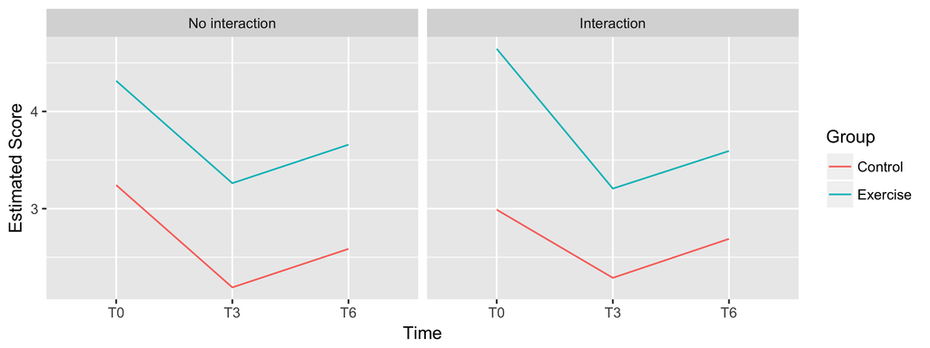

### Sleep Analysis

- The lines represent the model predicted survey scores by time and treatment
- A location effect was included in the model but averaged out before plotting
- The interaction term is not statistically significant (right figure)

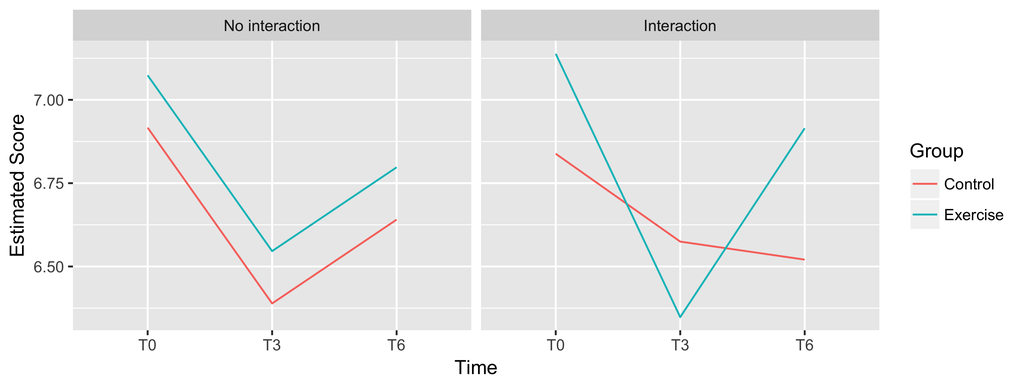

### Overall Quality of Life Analysis

- The lines represent the model predicted survey scores by time and treatment
- A location effect was included in the model but averaged out before plotting
- The interaction term is not statistically significant (right figure)

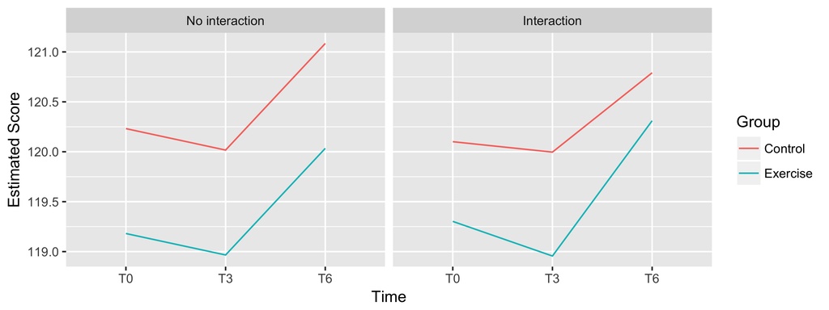

### Emotional Quality of Life Analysis

- The lines represent the model predicted survey scores by time and treatment
- A location effect was included in the model but averaged out before plotting
- The interaction term is not statistically significant (right figure)

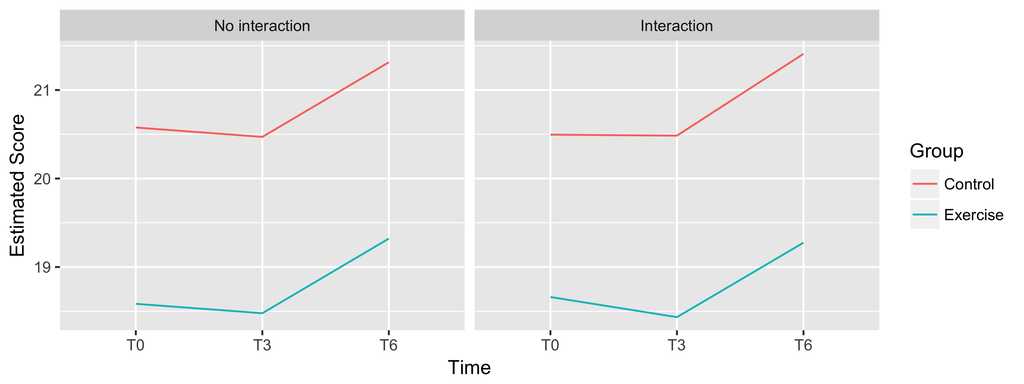

### Functional Quality of Life Analysis

- The lines represent the model predicted survey scores by time and treatment
- A location effect was included in the model but averaged out before plotting
- The interaction term is not statistically significant (right figure)

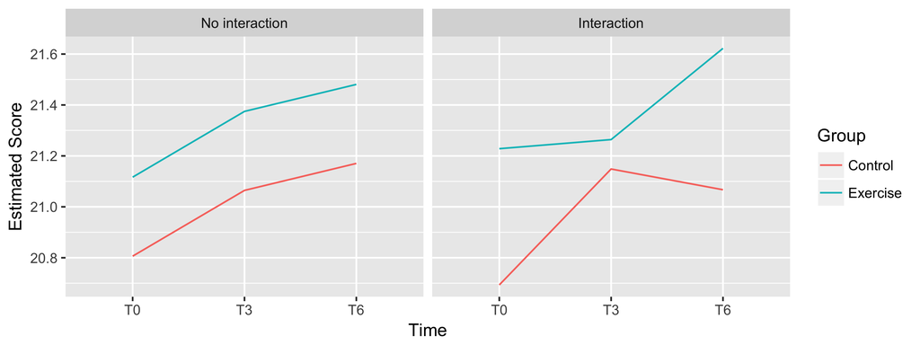

### Physical Quality of Life Analysis

- The lines represent the model predicted survey scores by time and treatment
- A location effect was included in the model but averaged out before plotting
- The interaction term is not statistically significant (right figure)

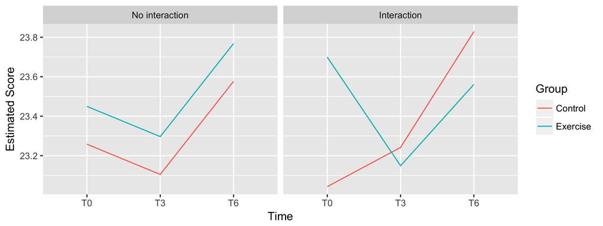

### Social/Family Quality of Life Analysis

- The lines represent the model predicted survey scores by time and treatment
- A location effect was included in the model but averaged out before plotting
- The interaction term is not statistically significant (right figure)

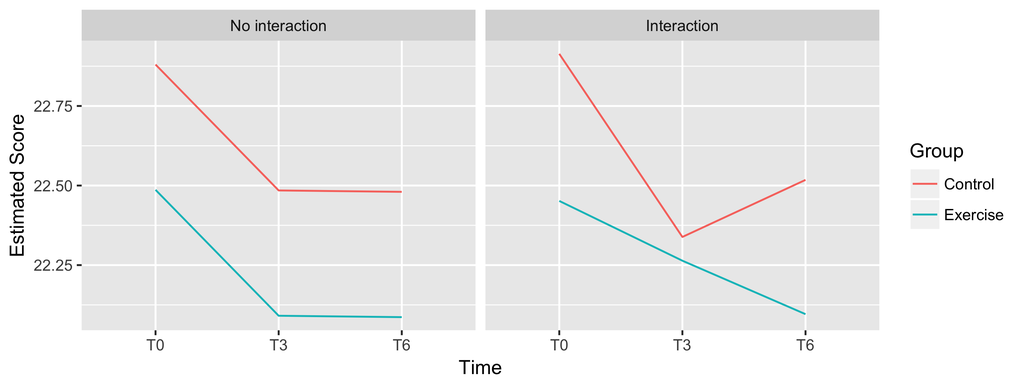

### Additional Quality of Life Analysis

- The lines represent the model predicted survey scores by time and treatment
- A location effect was included in the model but averaged out before plotting
- The interaction term is not statistically significant (right figure)

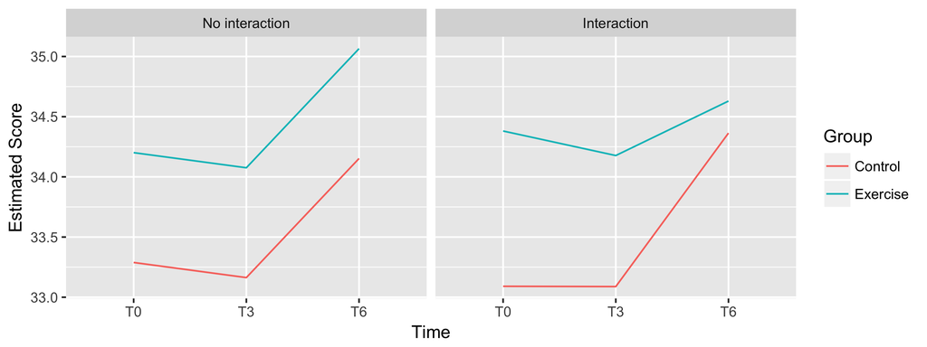

### Raw CTC Count Per Vial

- A generalized linear mixed model was fit to the individual CTC counts by Time, Location and a Time-by-Location interaction
- Patient data, such as BMI, Weight, Height, were also tried but were unimportnat
- WCC was statistically significant, but wasn't included in the model used to produce the figure below

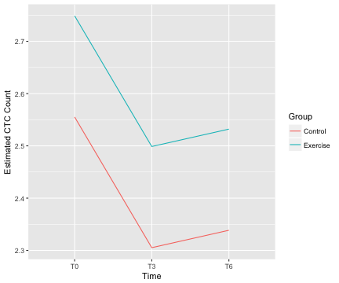

### Avg. CTCs 3mL

- A generalized linear mixed model was fit to the avg. CTC count per 3mL by Time, Location and a Time-by-Location interaction
- Patient data, such as BMI, Weight, Height, were also tried but were unimportnat
- WCC was statistically significant, but wasn't included in the model used to produce the figure below

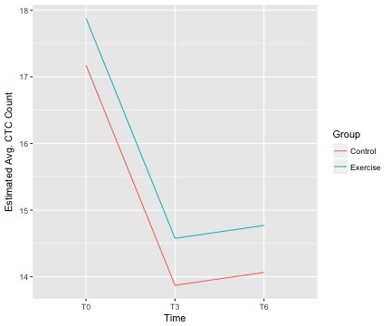